# Overview

# FordGoBike System Data

The FordGoBikeSystem dataset includes information about individual rides made in a bike-sharing system covering the greater San Francisco Bay area. in 2017.

Project Details:

1) Dataset : https://www.fordgobike.com/system-data  
2) Exploring Data  
3) Document the Story  
4) Communicating the Story

- Changing the datatypes of the variables appropriately

# Visualizations

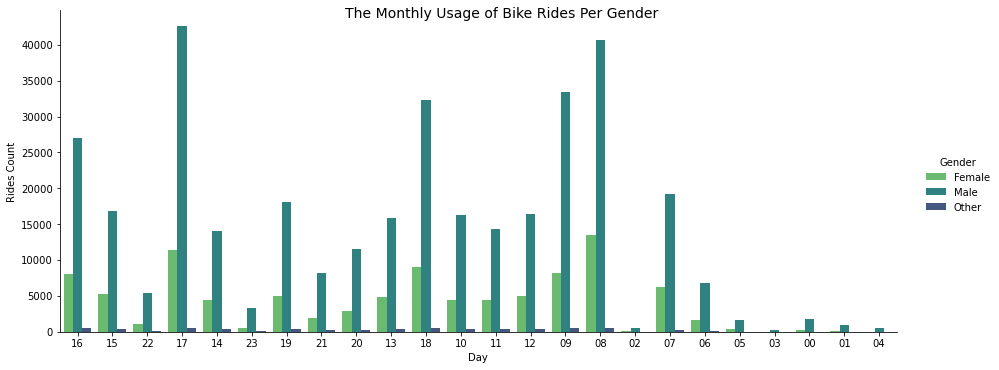

```python
x = sb.catplot(data=df_clean, x='start_hour_day', hue='member_gender', kind='count',aspect=20.7/8.27, palette='viridis_r')
x.set_axis_labels('Day', 'Rides Count')
x._legend.set_title('Gender')
x.fig.suptitle('The Monthly Usage of Bike Rides Per Gender', fontsize=14);
```

- Hourly usage of the bikes by Customers and Subscribers in this station

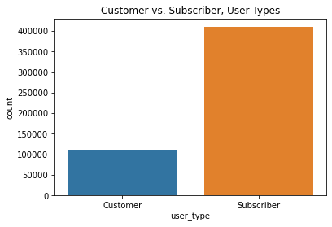

```python
sb.countplot(x='user_type', data=df_clean)
plt.title('Customer vs. Subscriber, User Types');
```

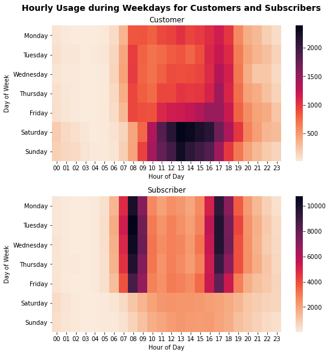

```python
plt.figure(figsize=[8, 8]);

plt.subplot(2, 1, 1)
customers = df_clean.query('user_type == "Customer"')
ct_counts = customers.groupby(['start_day_week', 'start_hour_day']).size()
ct_counts = ct_counts.reset_index(name='count')
ct_counts = ct_counts.pivot(index='start_day_week', columns='start_hour_day', values='count')
sb.heatmap(ct_counts, cmap='rocket_r');
plt.title('Customer', loc='center');
plt.xlabel('Hour of Day');
plt.ylabel('Day of Week');
plt.tight_layout();

plt.subplot(2, 1, 2)
subscribers = df_clean.query('user_type == "Subscriber"')
st_counts = subscribers.groupby(['start_day_week', 'start_hour_day']).size()
st_counts = st_counts.reset_index(name='count')
st_counts = st_counts.pivot(index='start_day_week', columns='start_hour_day', values='count')
sb.heatmap(st_counts, cmap='rocket_r');
plt.title('Subscriber', loc='center');
plt.xlabel('Hour of Day');
plt.ylabel('Day of Week');
plt.tight_layout();
plt.suptitle('Hourly Usage during Weekdays for Customers and Subscribers', fontsize=14, fontweight='semibold', y=1.015);
```

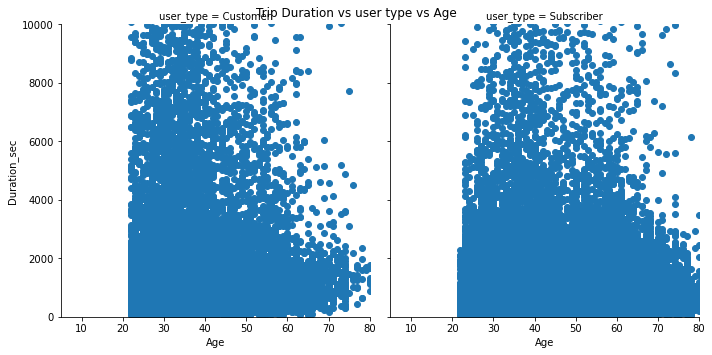

```python
x = sb.FacetGrid(data = df, col = 'user_type', col_wrap = 2, height = 5, xlim = [5, 80], ylim = [0, 10000])
x.map(plt.scatter, 'member_age', 'duration_sec', alpha= 1)
x.set_xlabels('Age')
x.set_ylabels('Duration_sec')
x.fig.suptitle('Trip Duration vs user type vs Age')
plt.show()
```

```python
plt.figure(figsize=[16, 6]);
base_color = sb.color_palette('colorblind')[0];
sb.set_style('darkgrid');

plt.subplot(1, 2, 1);
sorted_vals = df_clean.user_type.value_counts()/df_clean.shape[0];
plt.pie(sorted_vals, explode=[0, 0.1], labels=sorted_vals.index, startangle=90, counterclock=False, autopct='%1.1f%%', shadow=True);
plt.axis('square');

plt.subplot(1, 2, 2);
ax = sb.countplot(data=df_clean, x='start_month', hue='user_type', hue_order=sorted_vals.index);
ax.legend(title='User Type');
plt.xticks(rotation=30);
plt.xlabel('');
plt.ylabel('Count');
plt.suptitle('User Types and Their Monthly Usage', fontsize=14, fontweight='semibold', y=1.015);
```

[output not shown]

Different usage patterns between the two types of riders are clearly seen! Subscribers used the system heavily on work days. and customers ride a lot on weekends, especially in the afternoon yet casual customers tended to use more in the late afternoon around 17pm Monday to Friday.

# Summary

Main Findings from the Analysis:

This bike share system has greatly identified the need of the times and created a business that is profitable to both the end customers and the business. It is definitely a win-win Situation.

1) Between the User types, Customers and Subscribers the highest usage in terms of duration was by Customers in the year 2017  
2) Majority of the system’s bookings came through their app bookings – Lyft  
3) The station that received the highest demand in the year 2017 was the station 58 which as the Market St at 10th Street.  
However, after cleaning the data and removing all the bookings that were made through non-traditional booking methods which is app and dipper, the station with the highest demand was the station 296, which is 5th St at Virginia Street.  
4) The Station 296, the highest demand was on Tuesdays followed by Thursdays. The least demand was on Sundays.  
5) The User type who used this station the most were the Subscribers

There was a lot more subscribers using the bike sharing system than casual customers. Obviously different usage patterns are observed between the two types of riders. Subscribers used the system on work days, whereas customers ride a lot in weekends and in the afternoon for other purposes. Subscribers tended to have much shorter trips also.